# Report

### 0. Import and Load

### 1. Investigate Missing Data and Impute

We first look at the overall missingness in the dataset:

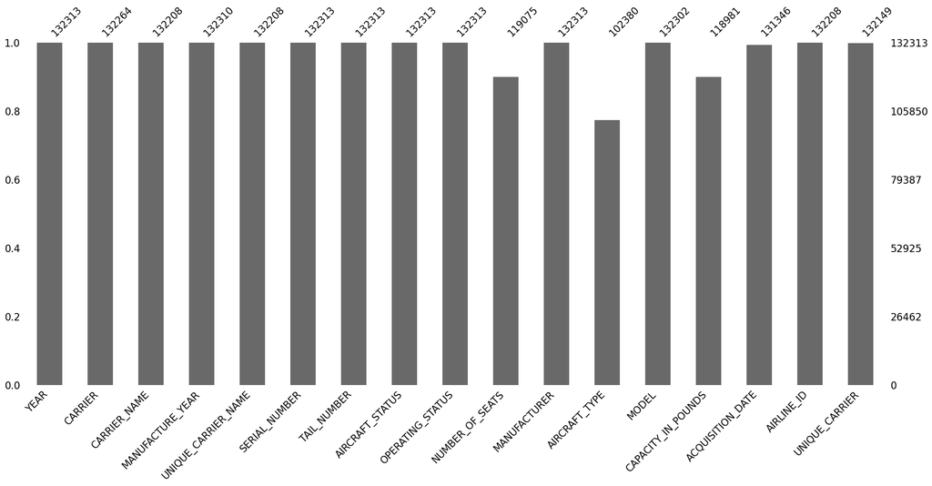

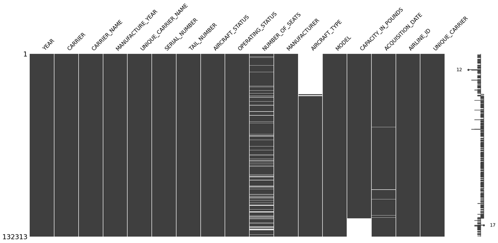

**`CARRIER`**

We observe that `CARRIER` has 49 missing values. However, we see that all of those missingness comes from `CARRIER_NAME` = North American Airlines. This airline has an IATA code of "NA", which is mistaken as "Not Available" by the dataset. We can impute this missingness by a constant value "NA".

**`CARRIER_NAME` and `AIRLINE_ID`**

There are 105 missing values in `CARRIER_NAME` and `AIRLINE_ID`. However, their `CARRIER` column values are not missing. We can use the carrier code to find out which carrier those missing rows belong to.

For carrier code L4, the corresponding airline is "Lynx Aviation d/b/a Frontier Airlines" and the airline_id is 21217.0.

For carrier code OH, there are two possible airlines: "Comair Inc." and "PSA Airlines Inc." We **cannot** say for sure which carrier those missing values belong to, and will not impute these rows.

**`MANUFACTURE_YEAR`**

We see 3 observations of missingness in this column. However, there's no obvious pattern or trend in those missing rows. Because the number of missing rows is extremely small, it's safe to not impute any values for those rows. We can drop these three rows later and not include them in our analysis.

**`NUMBER_OF_SEATS` and `CAPACITY_IN_POUNDS`**

There are 13238 missing values in the number of seats and 13332 missing values in the capacity.

```
YEAR                   49
CARRIER                 0
CARRIER_NAME           49
MANUFACTURE_YEAR       49
UNIQUE_CARRIER_NAME    49
SERIAL_NUMBER          49
TAIL_NUMBER            49
AIRCRAFT_STATUS        49
OPERATING_STATUS       49
NUMBER_OF_SEATS         0
MANUFACTURER           49
AIRCRAFT_TYPE          29
MODEL                  49
CAPACITY_IN_POUNDS     49
ACQUISITION_DATE       49
AIRLINE_ID             49
UNIQUE_CARRIER          0
dtype: int64

CARRIER_NAME
North American Airlines    49
Name: count, dtype: int64

YEAR                   105
CARRIER                105
CARRIER_NAME             0
MANUFACTURE_YEAR       105
UNIQUE_CARRIER_NAME      0
SERIAL_NUMBER          105
TAIL_NUMBER            105
AIRCRAFT_STATUS        105
OPERATING_STATUS       105
NUMBER_OF_SEATS        105
MANUFACTURER           105
AIRCRAFT_TYPE           97
MODEL                  105
CAPACITY_IN_POUNDS     105
ACQUISITION_DATE       105
AIRLINE_ID               0
UNIQUE_CARRIER           0
```

[output cut: 153 more lines]

```
MANUFACTURER           13332
AIRCRAFT_TYPE          13332
MODEL                  13332
CAPACITY_IN_POUNDS         0
ACQUISITION_DATE       13178
AIRLINE_ID             13332
UNIQUE_CARRIER         13332
dtype: int64

YEAR
2023    8229
2022    5002
2017      99
2018       2
Name: count, dtype: int64
```

From the missingno bargraph above, we see that the number of seats is most likely **missing at random (MAR)**. It's not MNAR because there isn't a cutoff where after a certain threshold all rows are missing. It's also safe to assume that this column is not MCAR because the missingness of `NUMBER_OF_SEATS` should be correlated with other variables, as shown by the differences in the correlation matrices below, comparing all numeric columns correlations before and after we drop all the NaN rows from this column.

|  | YEAR | MANUFACTURE_YEAR | NUMBER_OF_SEATS | CAPACITY_IN_POUNDS | AIRLINE_ID |
| --- | --- | --- | --- | --- | --- |
| YEAR | 0.000000 | 0.004913 | 0.0 | 0.001310 | -0.004980 |
| MANUFACTURE_YEAR | 0.004913 | 0.000000 | 0.0 | 0.006552 | -0.003648 |
| NUMBER_OF_SEATS | 0.000000 | 0.000000 | 0.0 | 0.000000 | 0.000000 |
| CAPACITY_IN_POUNDS | 0.001310 | 0.006552 | 0.0 | 0.000000 | -0.023173 |
| AIRLINE_ID | -0.004980 | -0.003648 | 0.0 | -0.023173 | 0.000000 |

Capacity is **Missing Not at Random (MNAR)** because there is a clear threshold for which its values are missing. As shown on the missingno bar graph above and inspecting the dataset, `CAPACITY_IN_POUNDS` is missing mostly when `YEAR` is after a certain time in 2022, and there are also some missing values before 2018.

To impute these two columns, we will use the predictive mean matching approach. This is a robust method that takes into consideration the multivariate relationships between the columns. Below we show visualizations of comparisons between the imputed and the unimputed data for both the number of seats and the capacity column. We have imputed multiple datasets with the MICE method. We have chosen to generate 5 datasets, with 3 mean matching candidates, and use 5 iterations. And after we complete the generation, we'll take the mean across all imputed datasets to create a final imputation to replace the missing data.

From the graphs, we observe that the imputations for both columns are all relatively close to the original unimputed datasets.

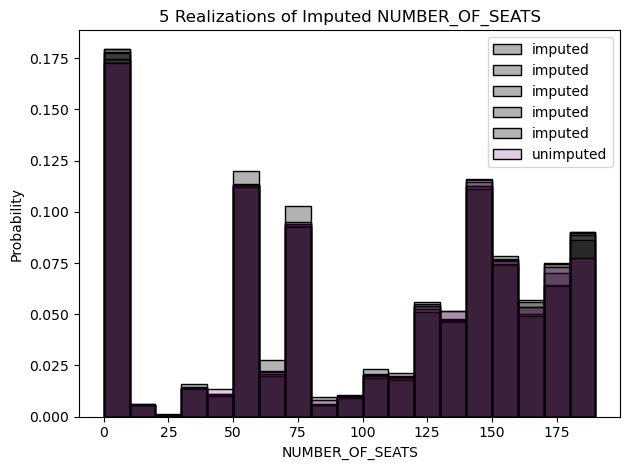

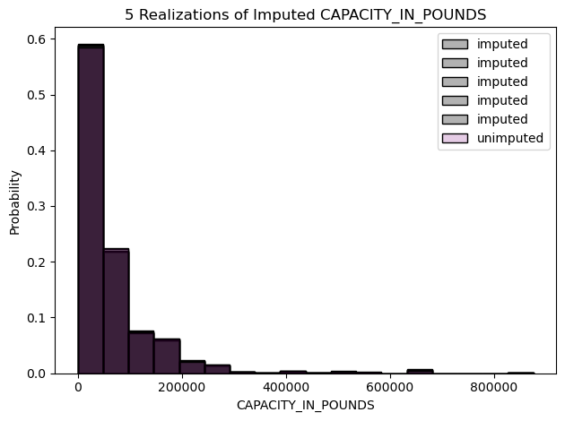

After the imputation, we confirm that the missingness is removed in carrier, part of carrier_name, number_of_seats, capacity_in_pounds, and part of airline_id.

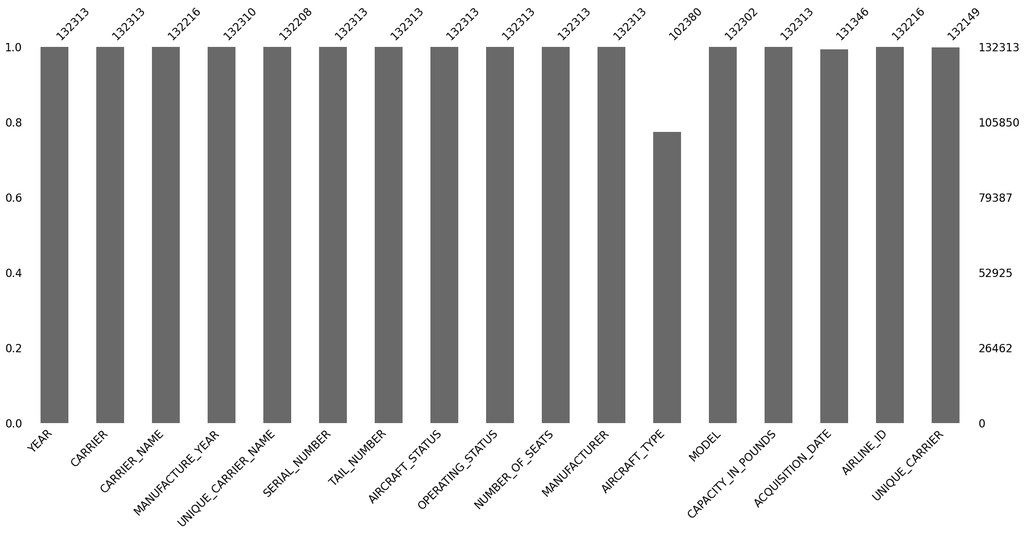

### 2. Transform and Standardize

We first inspect all the target columns and identify possible issues that requires transformation/standardization.

```
MANUFACTURER
BOEING                        15922
Embraer                       11508
THEBOEINGCO                    9223
Bombardier                     8871
Boeing                         8392
                              ...
SAABScania                        1
Dassault-Falcon-2000EXEASy        1
ISRAELAIRCRAFTINDUSTRIES          1
JPLEASE/CEBUPACIFIC               1
JSA/Peach                         1
Name: count, Length: 183, dtype: int64

MODEL
EMB-145             2614
B-737-7H4           2470
B737-823            2370
A320-232            2333
A321-231            2259
                    ...
FANJETFALCONSERD       1
Boeing737-4K5          1
737-4H6                1
Boeing737-883          1
ERJ170-200STD          1
Name: count, Length: 1340, dtype: int64

AIRCRAFT_STATUS
O    79487
b    30852
B    12699
a     7804
A     1330
L      122
o       19
Name: count, dtype: int64

OPERATING_STATUS
Y    126577
N      5664
y        71
          1
Name: count, dtype: int64
```

**`MANUFACTURER`**

This column requires some transformation. As shown by the presentation of unique values, there are some duplicate values that refer to the same manufacturer but are case sensitive, and recognized as two different unique entries. We will then standardize to have all manufacturer entries be capitalized.

Furthermore, we see cases such as 'BOEING' and 'THEBOEINGCO', where the company has suffix and prefix in the name. These two values are for the same company and should be identified as 'BOEING' after the transformation. To achieve this, we remove prefix 'THE' and suffices 'LTD', 'INC', 'CO', 'COMPANY', 'INDUSTRIES' that are common in company names.

The transformation reduces the number of unique values from 183 to 148.

**`MODEL`**

There are some duplicate values due to capitalization again. The transformation will first capitalize all letters to remove those redundancies.

We also see cases such as 'B-737' and 'B737' identified as two different models, but they're essentially the same. The solution is to remove all '-'.

Finally, there are some models using the company's full name, such as 'BOEING737', and some using the abbreviation, such as 'B737'. We will try to change the entries to use the abbreviations, but it's impossible to do so for all manufacturers; the code will perform this standardization for the top 3 manufacturers: Boeing, Airbus, and Embraer.

After transformation, the number of unique values in model reduced FROM 1340 to 1186.

**`AIRCRAFT_STATUS` and `OPERATING_STATUS`**

We see the same pattern with upper and lower case letters being identified as different values in these columns as well. To standardize, all entries will be transformed to uppercase.

We see that all entries are properly grouped into correct categories after the transformation: aircraft_status now has 'O', 'B', 'A', and 'L' as valid values, and operating_status now has only 'Y' and 'N' as valid values, with an unclear data point that indicates neither status.

```
MANUFACTURER
BOEING                        52122
AIRBUS                        19884
EMBRAER                       14795
BOMBARDIER                    11692
MCDONNELLDOUGLAS               4306
                              ...
MCDONNELL                         1
SAABSCANIA                        1
DASSAULT-FALCON-2000EXEASY        1
ISRAELAIRCRAFT                    1
JSA/PEACH                         1
Name: count, Length: 148, dtype: int64

MODEL
A320232    3020
EMB145     2757
B7377H4    2470
B737823    2370
A321231    2259
           ...
75729J        1
T210N         1
B7374K5       1
7374H6        1
B737883       1
Name: count, Length: 1186, dtype: int64

AIRCRAFT_STATUS
O    79506
B    43551
A     9134
L      122
Name: count, dtype: int64

OPERATING_STATUS
Y    126648
N      5664
          1
Name: count, dtype: int64
```

### 3. Remove Remaining Missing Data

We have a remaining of 101275 rows after removing missing values.

```
(101275, 20)
```

The following table shows the occurrances of NaN values in the remaining 101275 entries. We see that all columns have 'False', indicating that the entry is not missing, for all rows.

```
YEAR   CARRIER  CARRIER_NAME  MANUFACTURE_YEAR  UNIQUE_CARRIER_NAME  SERIAL_NUMBER  TAIL_NUMBER  AIRCRAFT_STATUS  OPERATING_STATUS  NUMBER_OF_SEATS  MANUFACTURER  AIRCRAFT_TYPE  MODEL  CAPACITY_IN_POUNDS  ACQUISITION_DATE  AIRLINE_ID  UNIQUE_CARRIER  NUMBER_OF_SEATS_BOXCOX  CAPACITY_IN_POUNDS_BOXCOX…
False  False    False         False             False                False          False        False            False             False            False         False          False  False               False             False       False           False                   False                    …
Name: count, dtype: int64
```

### 4. Transform and Derive Variables

The skewness in the variables `NUMBER_OF_SEATS` and `CAPACITY_IN_POUNDS` is shown below by the two histograms. We see that the number of seats have a tail on the right and the capacity has an even longer tail on the right.

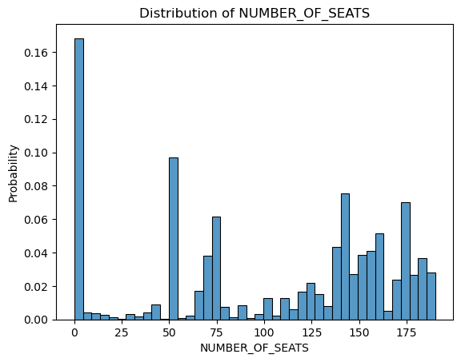

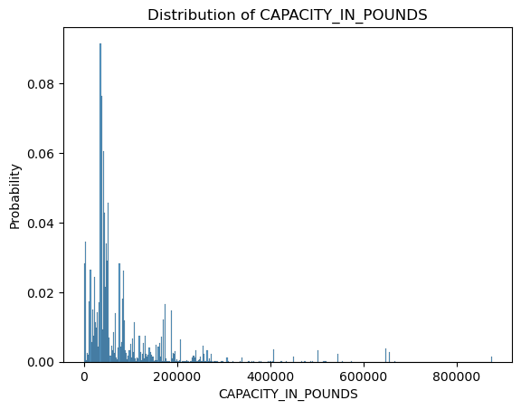

Below are the histograms of the same two variables after the box-cox transformation. We see that this transformation has shifted the shape of both distributions.

`NUMBER_OF_SEATS`

We see that the shape has shifted right. This is especially apparent with the peak that was originally at about 50 seats on the histogram above: this peak (now located at 20 on the boxcox histogram) has moved right in the transformed shape.

`CAPACITY_IN_POUNDS`

The change in shape is a lot more dramatic. We see that the post-transformation graph has an almost normal shape, with its center peak almost at the middle. For this column, the new histogram shows a near bell-shaped curve that looks very different than the skewed plot above.

For both of these variables, we also observe that the new columns have smaller value ranges. For example, the number of seats had a maximum of 175+, but now the number of seats boxcox column only has a maximum of 50.

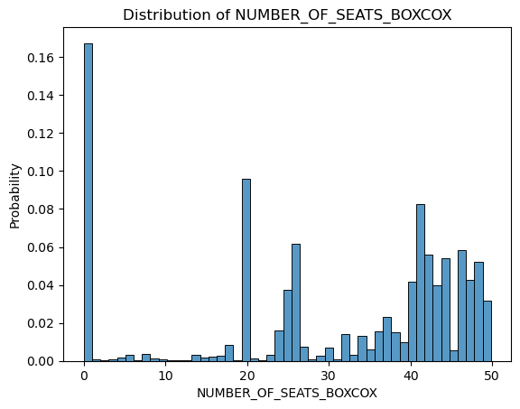

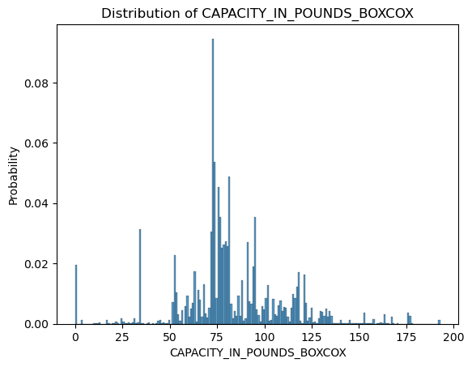

### 5. Feature Engineering

After creating the new column `SIZE`, we find for each size group, the proportions of aircrafts that are operating versus not, and also the proporitions of aircrafts that belong to each aircraft status group.

`OPERATING_STATUS`

Dsregarding the one unclear data point that is neither 'Y' nor 'N', most exihibit a similar trend: all size groups have mostly operating aircrafts. And as the aircraft size increases, the proportion of operating aircraft also increases: small planes have a proportion of 0.954 operating aircrafts, medium planes have 0.959, large planes have 0.963, and xlarge have 0.973.

`AIRCRAFT_STATUS`

We see that there are more status O planes, less status B, even less status A, and least status L across all size groups. And we see that in general, smaller planes have smaller porpotions of status O and larger proportions of status B than their larger counterparts. We also see a general increasing trend of status A planes as the size group increases, except at xlarge size where the proportion decreases to a little less than the proportion in medium.

```
     SIZE OPERATING_STATUS  count  total  proportion
0   SMALL                       1  29877    0.000033
1   SMALL                N   1379  29877    0.046156
2   SMALL                Y  28497  29877    0.953811
3  MEDIUM                N    863  21167    0.040771
4  MEDIUM                Y  20304  21167    0.959229
5   LARGE                N    941  25367    0.037095
6   LARGE                Y  24426  25367    0.962905
7  XLARGE                N    661  24864    0.026585
8  XLARGE                Y  24203  24864    0.973415
```

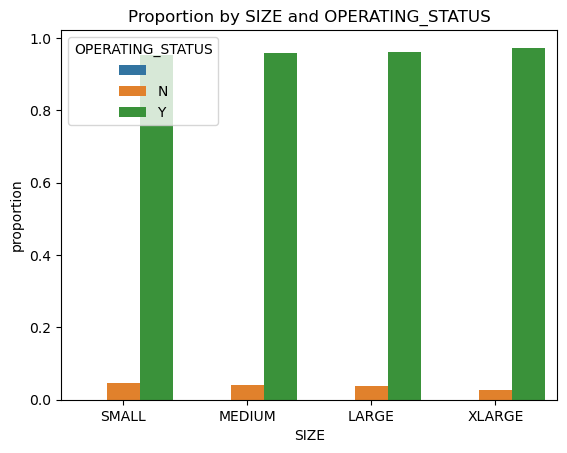

```
      SIZE AIRCRAFT_STATUS  count  total  proportion
0    SMALL               A   1223  29877    0.040934
1    SMALL               B  11855  29877    0.396794
2    SMALL               O  16799  29877    0.562272
3   MEDIUM               A   1726  21167    0.081542
4   MEDIUM               B   8116  21167    0.383427
5   MEDIUM               L     34  21167    0.001606
6   MEDIUM               O  11291  21167    0.533425
7    LARGE               A   2923  25367    0.115228
8    LARGE               B   4913  25367    0.193677
9    LARGE               L     56  25367    0.002208
10   LARGE               O  17475  25367    0.688887
11  XLARGE               A   1765  24864    0.070986
12  XLARGE               B   5618  24864    0.225949
13  XLARGE               L     32  24864    0.001287
14  XLARGE               O  17449  24864    0.701778
```

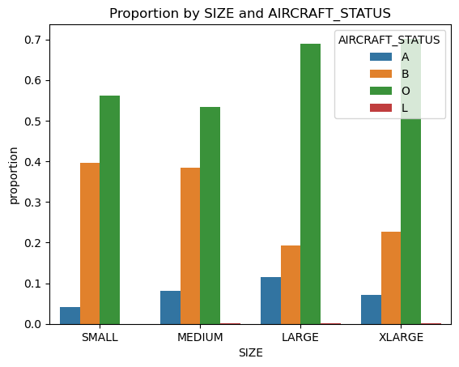

### 6. Modeling

Below we train 4 models of two types (random forest and linear) on two variables (number of seats and capacity in pounds). These results are obtained by removing the non-numeric columns, as well as the box-cox transformation columns (which are directly correlated with the number of seats and capacity in pounds before box-cox transformation, respectively), from the inventory dataset. We then scale the features and labels so that all columns are standardized and their magnitudes will not influence the models' predictions. We also split the data into 80% training and 20% testing.

We report the RMSEs for both the training and testing data prediction on each model. From them, we conclude that linear models perform worse than the random forest models, and capacity is harder to predict than the number of seats (resulting in higher RMSE for both types of models when predicting capacity).

We also see that the linear models have a smaller difference in training and testing RMSEs, while the random forest models have much better performance on the training data than the testing data. This probably means that the random forest models overfit to the given dataset more than the linear models.

```
---RESULTS FOR LINEAR MODEL ON NUMBER_OF_SEATS---
Training RMSE: 0.9050891050921432
Testing RMSE: 0.9077551570895771

---RESULTS FOR LINEAR MODEL ON CAPACITY_IN_POUNDS---
Training RMSE: 0.989511265188002
Testing RMSE: 1.0021210104376863

---RESULTS FOR RANDOM FOREST MODEL ON NUMBER_OF_SEATS---
Training RMSE: 0.055814091903473306
Testing RMSE: 0.08652161355893777

---RESULTS FOR RANDOM FOREST MODEL ON CAPACITY_IN_POUNDS---
Training RMSE: 0.20760548058968267
Testing RMSE: 0.2628727671644745
```